# Отчет по проектной работе №1: Обработка данных моллюсков

В ходе работы будут использованы библиотеки **dplyr** и **ggplot2**.

### 1. Единая таблица

Напишем функцию **load_data()**, которая на вход принимает путь к папке, в которой лежат *.csv* файлы, а возвращает датафрейм объединенных таблиц

```r
load_data <- function(path) {
  files <- dir(path, pattern = '*.csv', full.names = TRUE)
  tables <- lapply(files, read.csv)
  do.call(rbind, tables)
}
```

Применим её к нашим данным:

```r
data <- load_data("./Data")
```

### 2. Фильтрация

Посмотрим на данные:

```r
str(data)
```

```
## 'data.frame':    4177 obs. of  9 variables:
##  $ Rings                                 : chr  "18" "14" "8" "12" ...
##  $ Sex..1...male..2...female..3...uvenil.: chr  "2" "3" "1" "1" ...
##  $ Length                                : chr  "0.575" "0.385" "0.475" "0.665" ...
##  $ Diameter                              : num  0.45 0.305 0.37 0.525 0.12 0.16 0.565 0.43 0.175 0.3 ...
##  $ Height                                : num  0.17 0.095 0.125 0.18 0.075 0.05 0.2 0.15 0.055 0.115 ...
##  $ Whole_weight                          : num  1.048 0.252 0.649 1.429 0.117 ...
##  $ Shucked_weight                        : num  0.3775 0.0915 0.347 0.6715 0.0455 ...
##  $ Viscera_weight                        : num  0.171 0.055 0.136 0.29 0.029 ...
##  $ Shell_weight                          : num  0.385 0.09 0.142 0.4 0.0345 0.015 0.494 0.221 0.018 0.0935 ...
```

Не очень хорошо, что число колец и длина – номинативные переменные, когда они должны быть числовыми. Исправим это. Также, название колонки для пола не совсем корректно. Это тоже можно исправить.

```r
data <- data %>% mutate(Rings = as.numeric(Rings), Length = as.numeric(Length))
colnames(data)[2] <- "Sex"
```

Ну и конечно, нужно избавиться от NA. Один из наиболее употребимых подходов – замена всех NA на средние значения:

```r
replace_na_to_mean <- function(x){
  ifelse(is.na(x), mean(x, na.rm = T), x)
}
```

Но мы им пользоваться не будем. Заметим, что в нашем случае, количество строк с NA много меньше количества наблюдений, поэтому дабы не портить статистику, лучше наблюдения с NA вычеркнуть из данных.

```r
row.has.na <- apply(data, 1, function(x){any(is.na(x))})
data_without_NA <- data[!row.has.na,]
```

Также заменим неправильные обозначения для пола моллюска:

```r
data_without_NA[data_without_NA$Sex == "male", ]$Sex <- '1'
data_without_NA[data_without_NA$Sex == "one", ]$Sex <- '1'
data_without_NA[data_without_NA$Sex == "three", ]$Sex <- '3'
```

### 3. Среднее значение и стандартное отклонение переменной Length для моллюсков разного пола.

```r
data_without_NA %>% group_by(Sex) %>% summarise(mean = mean(Length), sd = sd(Length))
```

```
## # A tibble: 3 x 3
##   Sex    mean     sd
##   <chr> <dbl>  <dbl>
## 1 1     0.562 0.103
## 2 2     0.579 0.0862
## 3 3     0.428 0.109
```

### 4. Процент моллюсков, для которых значение переменной Height не превышает 0.165.

```r
100 * nrow(data_without_NA[data_without_NA$Height <= 0.165, ]) / nrow(data_without_NA)
```

```
## [1] 75.83634
```

### 5. Значение переменной Length, которое выше чем у 92% от всех наблюдений

```r
quantile(data_without_NA$Length, probs = c(0.92))
```

```
##  92%
## 0.67
```

### 6. Значения переменной Length после её стандартизации.

```r
Lenght_z_scores <- (data_without_NA$Length - mean(data_without_NA$Length)) / sd(data_without_NA$Length)
```

### 7. Сравнение между собой диаметров моллюсков с числом колец 5 и 15.

Построим график плотностей распределений для моллюсков с 5 кольцами и 15 кольцами.

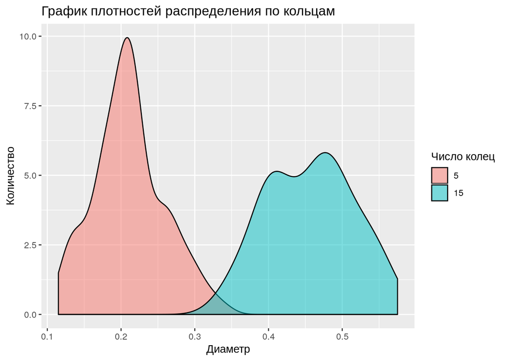

```r
rings_5 <- data_without_NA[data_without_NA$Rings == 5, ]
rings_15 <- data_without_NA[data_without_NA$Rings == 15, ]
rings_5_15 <- rbind(rings_5, rings_15)

ggplot(rings_5_15, aes(x = rings_5_15$Diameter, fill = factor(Rings))) +
  geom_density(alpha = 0.5)+
  xlab("Диаметр")+
  ylab("Количество")+
  scale_fill_discrete(name="Число колец")+
  ggtitle("График плотностей распределения по кольцам")
```

Смотря на графики, можно выдвинуть две гипотезы: H0 – математические ожидания одинаковые или H1 – математические ожидания различаются для моллюсков с количеством колец 5 и 15. Чтобы проводить тест, посмотрим, нормально ли распределены данные с помощью теста Шапиро-Вилка:

```r
shapiro.test(data_without_NA$Diameter)
```

```
##
##  Shapiro-Wilk normality test
##
## data:  data_without_NA$Diameter
## W = 0.97041, p-value < 2.2e-16
```

Судя по результату, данные имеют не нормальное распределение, поэтому проверять свои гипотезы будем с помощью теста Манна-Уитни.

```r
wilcox.test(Diameter ~ Rings, data = data_without_NA, subset = Rings %in% c(5, 15))
```

```
##
##  Wilcoxon rank sum test with continuity correction
##
## data:  Diameter by Rings
## W = 1, p-value < 2.2e-16
## alternative hypothesis: true location shift is not equal to 0
```

### 8. Корреляция Diameter и Whole_weight.

Посмотрим, как соотносятся данные переменные:

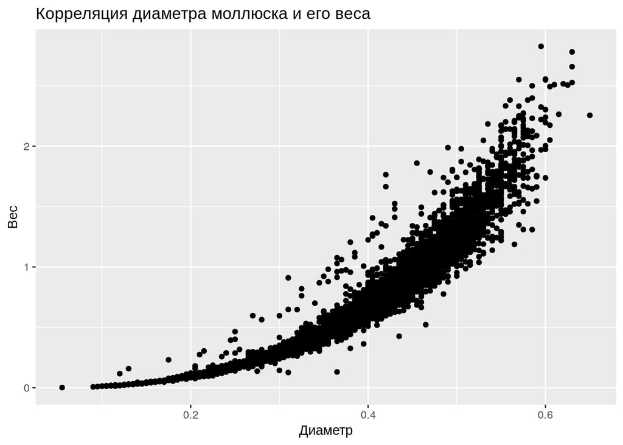

```r
ggplot(data_without_NA, aes(x = Diameter, y = Whole_weight)) +
  geom_point() +
  xlab("Диаметр")+
  ylab("Вес")+
  ggtitle("Корреляция диаметра моллюска и его веса")
```

Во-первых, мы видим параболу, что означает корреляцию степенной зависимости диаметра и значения веса всего моллюска. Логично, что объем растет по кубу от линейного размера, а диаметр – это как раз линейный размер, а вес линейно зависит от объема. Таким образом, проверим гипотезу о корреляции между кубом от значения диаметра моллюска и его весом.

```r
cor.test(data_without_NA$Diameter, (data_without_NA$Whole_weight) ** (1/3))
```

```
##
##  Pearson's product-moment correlation
##
## data:  data_without_NA$Diameter and (data_without_NA$Whole_weight)^(1/3)
## t = 302.23, df = 4153, p-value < 2.2e-16
## alternative hypothesis: true correlation is not equal to 0
## 95 percent confidence interval:
##  0.9766511 0.9792982
## sample estimates:
##      cor
## 0.978014
```

с p-value около 0 отвергаем H0-гипотезу о том, что они не скоррелированы. Нарисуем график:

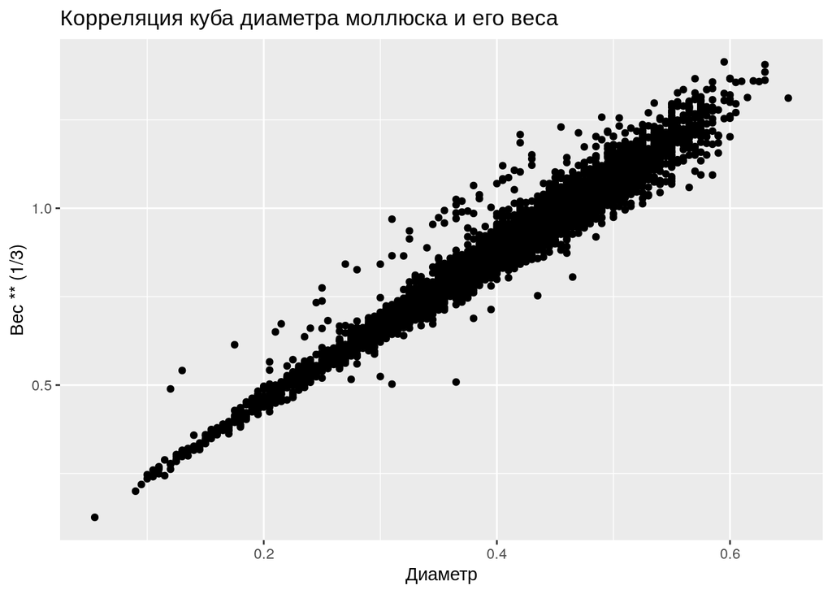

```r
ggplot(data_without_NA, aes(x = Diameter, y = Whole_weight ** (1/3))) +
  geom_point() +
  xlab("Диаметр")+
  ylab("Вес ** (1/3)")+
  ggtitle("Корреляция куба диаметра моллюска и его веса")
```

### 9. Различия числа колец у особей разного возраста.

Есть основания предполагать, что у малышей моллюсков колец будет меньше, чем у взрослых. Также возможно у мужских особей количество колец будет отличаться от оного у женских особей. Посмотрим на графики.

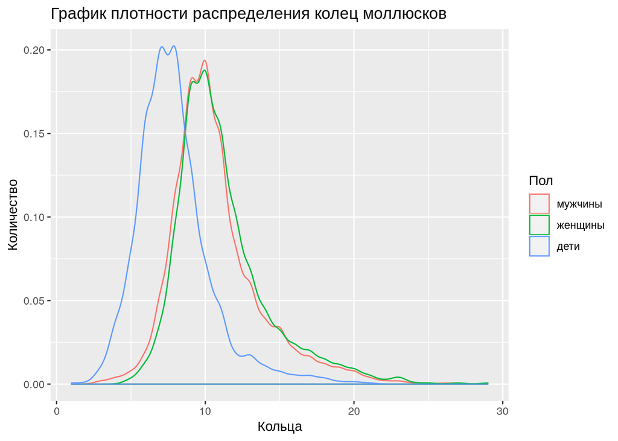

```r
ggplot(data_without_NA, aes(x = data_without_NA$Rings, col = factor(Sex, labels = c("мужчины", 'женщины', 'дети')))) +
  geom_density()+
  xlab("Кольца")+
  ylab("Количество")+
  labs(col = "Пол")+
  ggtitle("График плотности распределения колец моллюсков")
```

Проверим данные на нормальность:

```r
shapiro.test(data_without_NA$Rings)
```

```
##
##  Shapiro-Wilk normality test
##
## data:  data_without_NA$Rings
## W = 0.93125, p-value < 2.2e-16
```

Данные не являются нормальными, поэтому проведем тесты Манна-Уитни:

```r
wilcox.test(Rings ~ Sex, data = data_without_NA, subset = Sex %in% c("1", "3"), alternative='greater')
```

```
##
##  Wilcoxon rank sum test with continuity correction
##
## data:  Rings by Sex
## W = 1619966, p-value < 2.2e-16
## alternative hypothesis: true location shift is greater than 0
```

Да, средние количества колец значимо различаются у детей и взрослых особей, у взрослых их больше.

```r
wilcox.test(Rings ~ Sex, data = data_without_NA, subset = Sex %in% c("1", "2"),  alternative="less")
```

```
##
##  Wilcoxon rank sum test with continuity correction
##
## data:  Rings by Sex
## W = 905762, p-value = 6.243e-05
## alternative hypothesis: true location shift is less than 0
```

Удивительно, что мужские и женщинские особи тоже отличаются по числу колец: притом значимо больше колец у женских по сравнению с мужскими (тест был односторонним).

### 10. Корреляция веса ракушки и внутренности

Гипотеза: вес ракушки и ее заполнения коррелирует. Посмотрим график. Рассчитаем тест.

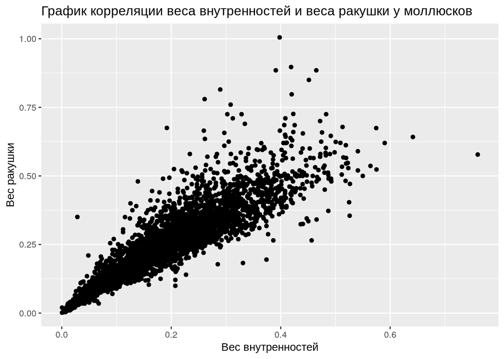

```r
ggplot(data_without_NA, aes(x = Viscera_weight, y = Shell_weight)) +
  geom_point()+
  xlab("Вес внутренностей")+
  ylab("Вес ракушки")+
  ggtitle("График корреляции веса внутренностей и веса ракушки у моллюсков")
```

```r
cor.test(data_without_NA$Viscera_weight, data_without_NA$Shell_weight, method = "spearm")
```

```
##
##  Spearman's rank correlation rho
##
## data:  data_without_NA$Viscera_weight and data_without_NA$Shell_weight
## S = 741781854, p-value < 2.2e-16
## alternative hypothesis: true rho is not equal to 0
## sample estimates:
##       rho
## 0.9379539
```

Судя по тесту, действительно, коррелируют.

### 11. Построение множественной регрессионной модели для значения веса моллюска.

Есть веские основания полагать, что общий вес моллюска складывается из веса раковины, веса внутренностей и веса почищенного моллюска. Построим линейную модель, описывающую “веса весов в общем весе” для моллюска, то есть какая часть от веса моллюска вносит бОльший вклад в общий вес моллюска.

```r
weight.lm <- lm(Whole_weight ~ Shucked_weight+Viscera_weight+Shell_weight, data_without_NA)
summary(weight.lm)
```

```
##
## Call:
## lm(formula = Whole_weight ~ Shucked_weight + Viscera_weight +
##     Shell_weight, data = data_without_NA)
##
## Residuals:
##      Min       1Q   Median       3Q      Max
## -0.54678 -0.01704 -0.00193  0.00903  0.51729
##
## Coefficients:
##                 Estimate Std. Error t value Pr(>|t|)
## (Intercept)    -0.007823   0.001457  -5.368 8.41e-08 ***
## Shucked_weight  0.935739   0.009316 100.444  < 2e-16 ***
## Viscera_weight  1.112807   0.021137  52.647  < 2e-16 ***
## Shell_weight    1.253159   0.012824  97.721  < 2e-16 ***
## ---
## Signif. codes:  0 '***' 0.001 '**' 0.01 '*' 0.05 '.' 0.1 ' ' 1
##
## Residual standard error: 0.04694 on 4151 degrees of freedom
## Multiple R-squared:  0.9908, Adjusted R-squared:  0.9908
## F-statistic: 1.498e+05 on 3 and 4151 DF,  p-value: < 2.2e-16
```

В построенной модели, во первых, мы видим интерсепт чуть меньше нуля (конечно, хотелось бы увидеть здесь ноль, но это тоже не так уж и плохо). Во-вторых, можем сделать вывод, что для линейного приближения, вес раковины вносит наибольший вклад в общий вес моллюска, но в целом незначительно больше. При этом, наша модель объясняет 99% дисперсии, что говорит о том, что такая модель имеет довольно хорошую предсказательную силу (в интерполяционном смысле). Если смотреть на остатки, то в целом они не имеют нормальное распределение, но в серединке интервала можем считать, что они нормальны.

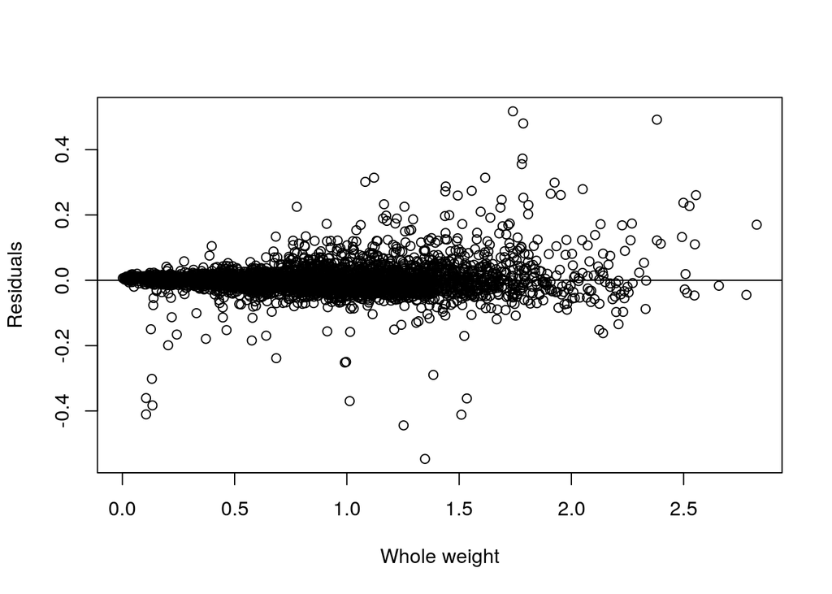

```r
plot(data_without_NA$Whole_weight, resid(weight.lm), ylab="Residuals", xlab="Whole weight")
abline(0, 0)
```